# Lab 1

Author

Owen Barberie

# Task 1

## Task 1.1

First, the size of the bubbles is based on population. Second, the color of the bubbles is based on geographic location. Third, the Y of the visual represents Life Expectancy. Lastly, the x axis demonstrates income.

## Task 1.2

```python
import pandas as pd
import plotnine as p9
from plotnine import *
from matplotlib.ticker import FixedLocator
```

```python
q1df = pd.read_csv('q1data.csv')
```

## Task 1.3

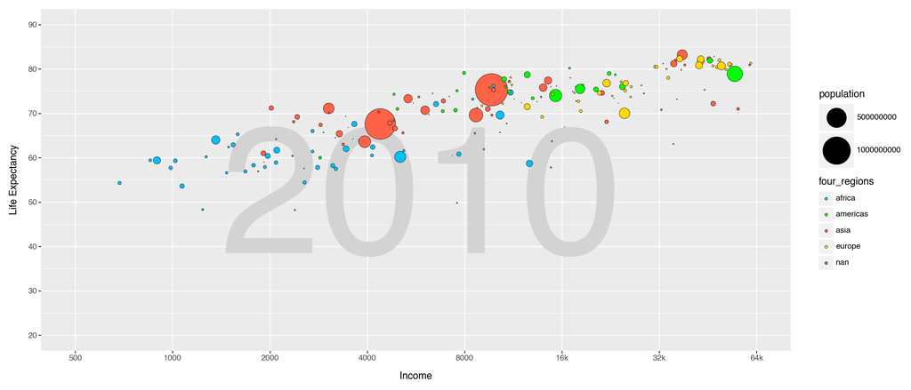

```python
region_colors = {'africa':'deepskyblue', 'americas':'lime', 'asia':'tomato', 'europe':'gold'}

(ggplot(q1df, aes(x='income',
y='life_exp',
size='population',
fill='four_regions',
label='country'))+
geom_text(aes(x=1400, y = 30, label = "2010"), size = 200, color = "lightgrey", alpha = .1, ha='left', va="bottom") +
geom_point(color = "black", stroke = .2 )+
labs(x="Income", y="Life Expectancy")+
scale_x_continuous(limits = (500,64000),breaks=[500, 1000, 2000, 4000, 8000, 16000, 32000, 64000],trans='log2',labels=[500, 1000, 2000, 4000, 8000, '16k', '32k', '64k'])+
scale_y_continuous(limits=(20,90),breaks=range(20,91, 10))+
scale_size_continuous(range=(0, 20))+
theme(figure_size = (14,6)) +
scale_fill_manual(values=region_colors)
)
```

## Task 1.4

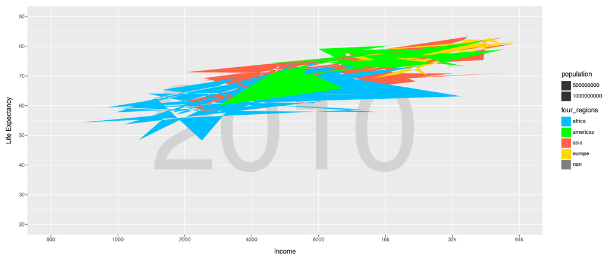

```python
region_colors = {'africa':'deepskyblue', 'americas':'lime', 'asia':'tomato', 'europe':'gold'}

(ggplot(q1df, aes(x='income',
y='life_exp',
size='population',
fill='four_regions',
label='country'))+
geom_text(aes(x=1400, y = 30, label = "2010"), size = 200, color = "lightgrey", alpha = .1, ha='left', va="bottom") +
geom_polygon( )+
labs(x="Income", y="Life Expectancy")+
scale_x_continuous(limits = (500,64000),breaks=[500, 1000, 2000, 4000, 8000, 16000, 32000, 64000],trans='log2',labels=[500, 1000, 2000, 4000, 8000, '16k', '32k', '64k'])+
scale_y_continuous(limits=(20,90),breaks=range(20,91, 10))+
scale_size_continuous(range=(0, 20))+
theme(figure_size = (14,6)) +
scale_fill_manual(values=region_colors)
)
```

Compared to the geom point visual created above, this geom_polygon is pretty ineffective in displaying anything of importance. Partially do to the parameters of the previous graph created with geom_point.